# Predict bike rental to reduce costs and improve customer satisfaction

#### using Decision Tree, Random Forest and Neural Network

#### ML2 Project with Robert Wojciechowski

Link to dataset: https://archive.ics.uci.edu/ml/datasets/bike+sharing+dataset

Dataset structure:

- **instant**: Unique ID for each row.
- **dteday**: Date (in format YYYY-MM-DD)
- **season**: Season (1:winter, 2:spring, 3:summer, 4:fall)
- **yr**: Year (0: 2011, 1:2012)
- **mnth**: Month (1 to 12)
- **holiday**: If it's holiday (extracted from https://dchr.dc.gov/page/holiday-schedules)
- **weekday**: Which day of the week (integer)
- **workingday**: If day is neither weekend nor holiday is 1, otherwise is 0 (not all holiday are bank holiday)
- **weathersit**:
  - 1: Clear, Few clouds, Partly cloudy, Partly cloudy
  - 2: Mist + Cloudy, Mist + Broken clouds, Mist + Few clouds, Mist
  - 3: Light Snow, Light Rain + Thunderstorm + Scattered clouds, Light Rain + Scattered clouds
  - 4: Heavy Rain + Ice Pallets + Thunderstorm + Mist, Snow + Fog
- **temp** : Normalized temperature in Celsius. The values are derived via (t-t_min)/(t_max-t_min), t_min=-8, t_max=+39 (only in hourly scale)
- **atemp**: Normalized feeling temperature in Celsius. The values are derived via (t-t_min)/(t_max-t_min), t_min=-16, t_max=+50 (only in hourly scale)
- **hum**: Normalized humidity. The values are divided to 100 (max)
- **windspeed**: Normalized wind speed. The values are divided to 67 (max)
- **casual**: count of casual users
- **registered**: count of registered users
- **cnt**: count of total rental bikes including both casual and registered

# About the model

Can I create a model that, for a given set of characteristics (weather conditions, holiday or not, season, day of the week, etc.), can accurately predict how many bikes will be rented?

Generally bike rental services have some **significant costs related to the insurance**, and this of course depends on how many people will rent a bike because:

### More clients rent public bikes → Higher chance of a damaged bike → Higer costs of insurance

But the problem is not only about the costs, because by predicting the bike usage the company can **improve their client satisfaction.**

## How?

If the company knows that in few days there's a high chance of a huge bike rentals, they can deliver a targeted maintainance service and there will be much less chance that a client finds a damaged bike.

# Introduction

Importing the required libraries to create the three models mentioned above:

```python
!pip install fancyimpute

import numpy as np
import pandas as pd
import matplotlib.pyplot as plt
import seaborn as sns
import scipy
import pydot
import graphviz
import math
import tensorflow as tf
from tensorflow import keras

from sklearn.model_selection import train_test_split
from fancyimpute import KNN
from sklearn import preprocessing, metrics, linear_model, tree
from sklearn.model_selection import cross_val_score, cross_val_predict, train_test_split, KFold
from sklearn.tree import DecisionTreeRegressor
from sklearn.ensemble import RandomForestRegressor
from sklearn.pipeline import Pipeline

from keras.models import Sequential
from keras.layers import Dense
from keras import layers
```

```
     |████████████████████████████████| 154 kB 18.9 MB/s
```

## Exploring the dataset

```python
df = pd.read_csv("day.csv")
```

```python
print(df.shape)
df.head()
```

```
(731, 16)
```

|  | instant | dteday | season | yr | mnth | holiday | weekday | workingday | weathersit | temp | atemp | hum | windspeed | casual | registered | cnt |
| --- | --- | --- | --- | --- | --- | --- | --- | --- | --- | --- | --- | --- | --- | --- | --- | --- |
| 0 | 1 | 2011-01-01 | 1 | 0 | 1 | 0 | 6 | 0 | 2 | 0.344167 | 0.363625 | 0.805833 | 0.160446 | 331 | 654 | 985 |
| 1 | 2 | 2011-01-02 | 1 | 0 | 1 | 0 | 0 | 0 | 2 | 0.363478 | 0.353739 | 0.696087 | 0.248539 | 131 | 670 | 801 |
| 2 | 3 | 2011-01-03 | 1 | 0 | 1 | 0 | 1 | 1 | 1 | 0.196364 | 0.189405 | 0.437273 | 0.248309 | 120 | 1229 | 1349 |
| 3 | 4 | 2011-01-04 | 1 | 0 | 1 | 0 | 2 | 1 | 1 | 0.200000 | 0.212122 | 0.590435 | 0.160296 | 108 | 1454 | 1562 |
| 4 | 5 | 2011-01-05 | 1 | 0 | 1 | 0 | 3 | 1 | 1 | 0.226957 | 0.229270 | 0.436957 | 0.186900 | 82 | 1518 | 1600 |

We have 731 rows (two years) and 16 features, our dependent variable is **cnt**.

```python
df.dtypes
```

```
instant         int64
dteday         object
season          int64
yr              int64
mnth            int64
holiday         int64
weekday         int64
workingday      int64
weathersit      int64
temp          float64
atemp         float64
hum           float64
windspeed     float64
casual          int64
registered      int64
cnt             int64
dtype: object
```

Rename the columns for a better understanding of variables

```python
df.rename(columns={
    'instant':'id',
    'dteday':'datetime',
    'yr':'year',
    'mnth':'month',
    'weathersit':'weather_condition',
    'hum':'humidity',
    'cnt':'total_count'
  }, inplace=True)
```

```python
df.head()
```

|  | id | datetime | season | year | month | holiday | weekday | workingday | weather_condition | temp | atemp | humidity | windspeed | casual | registered | total_count |
| --- | --- | --- | --- | --- | --- | --- | --- | --- | --- | --- | --- | --- | --- | --- | --- | --- |
| 0 | 1 | 2011-01-01 | 1 | 0 | 1 | 0 | 6 | 0 | 2 | 0.344167 | 0.363625 | 0.805833 | 0.160446 | 331 | 654 | 985 |
| 1 | 2 | 2011-01-02 | 1 | 0 | 1 | 0 | 0 | 0 | 2 | 0.363478 | 0.353739 | 0.696087 | 0.248539 | 131 | 670 | 801 |
| 2 | 3 | 2011-01-03 | 1 | 0 | 1 | 0 | 1 | 1 | 1 | 0.196364 | 0.189405 | 0.437273 | 0.248309 | 120 | 1229 | 1349 |
| 3 | 4 | 2011-01-04 | 1 | 0 | 1 | 0 | 2 | 1 | 1 | 0.200000 | 0.212122 | 0.590435 | 0.160296 | 108 | 1454 | 1562 |
| 4 | 5 | 2011-01-05 | 1 | 0 | 1 | 0 | 3 | 1 | 1 | 0.226957 | 0.229270 | 0.436957 | 0.186900 | 82 | 1518 | 1600 |

Now i cast variable to their appropriate data type:

```python
#Type casting the datetime and numerical attributes to category
df['datetime'] = pd.to_datetime(df.datetime)
df['season'] = df.season.astype('category')
df['year'] = df.year.astype('category')
df['month'] = df.month.astype('category')
df['holiday'] = df.holiday.astype('category')
df['weekday'] = df.weekday.astype('category')
df['workingday'] = df.workingday.astype('category')
df['weather_condition'] = df.weather_condition.astype('category')
```

```python
df.describe()
```

|  | id | temp | atemp | humidity | windspeed | casual | registered | total_count |
| --- | --- | --- | --- | --- | --- | --- | --- | --- |
| count | 731.000000 | 731.000000 | 731.000000 | 731.000000 | 731.000000 | 731.000000 | 731.000000 | 731.000000 |
| mean | 366.000000 | 0.495385 | 0.474354 | 0.627894 | 0.190486 | 848.176471 | 3656.172367 | 4504.348837 |
| std | 211.165812 | 0.183051 | 0.162961 | 0.142429 | 0.077498 | 686.622488 | 1560.256377 | 1937.211452 |
| min | 1.000000 | 0.059130 | 0.079070 | 0.000000 | 0.022392 | 2.000000 | 20.000000 | 22.000000 |
| 25% | 183.500000 | 0.337083 | 0.337842 | 0.520000 | 0.134950 | 315.500000 | 2497.000000 | 3152.000000 |
| 50% | 366.000000 | 0.498333 | 0.486733 | 0.626667 | 0.180975 | 713.000000 | 3662.000000 | 4548.000000 |
| 75% | 548.500000 | 0.655417 | 0.608602 | 0.730209 | 0.233214 | 1096.000000 | 4776.500000 | 5956.000000 |
| max | 731.000000 | 0.861667 | 0.840896 | 0.972500 | 0.507463 | 3410.000000 | 6946.000000 | 8714.000000 |

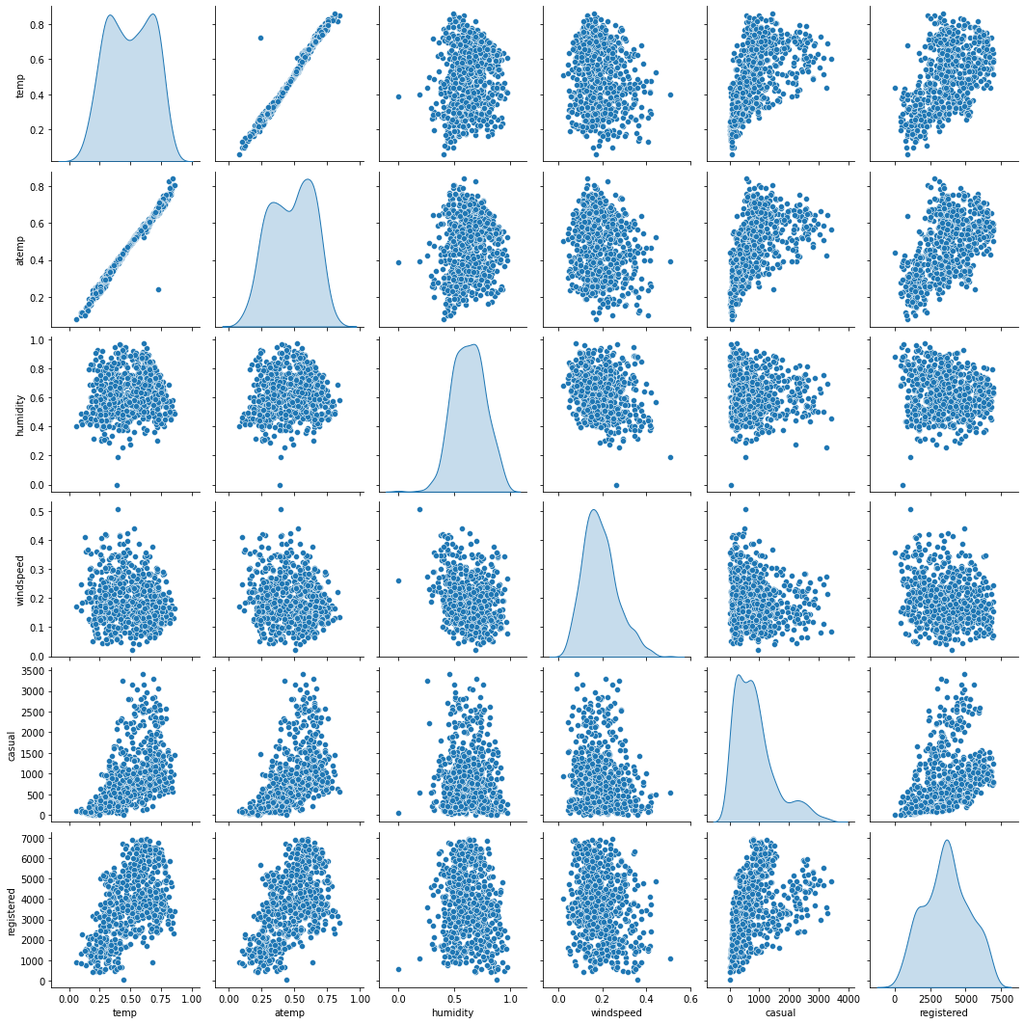

```python
sns.pairplot(df[["temp", "atemp", "humidity", "windspeed",	"casual",	"registered"]], diag_kind='kde')
```

```python
# Check if missing values
df.isnull().sum()
```

```
id                   0
datetime             0
season               0
year                 0
month                0
holiday              0
weekday              0
workingday           0
weather_condition    0
temp                 0
atemp                0
humidity             0
windspeed            0
casual               0
registered           0
total_count          0
dtype: int64
```

There are no missing values in the dataset.

# Exploratory Data Analysis (EDA)

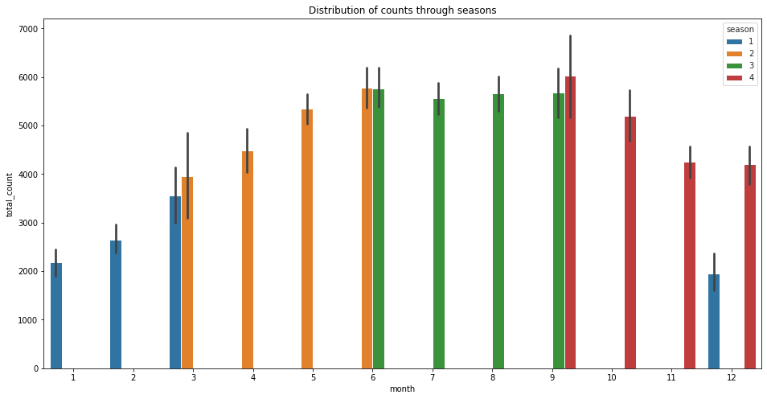

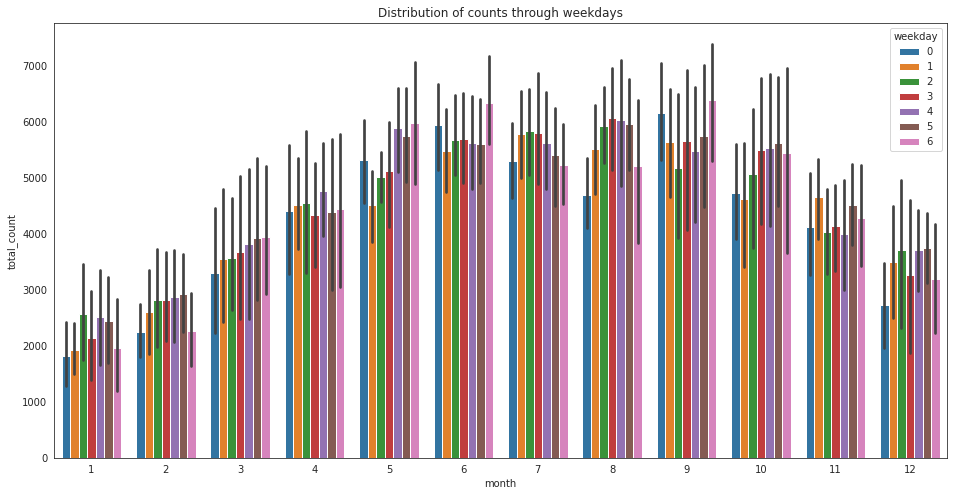

```python
fig,ax=plt.subplots(figsize=(16,8))
sns.set_style('white')

sns.barplot(x='month',y='total_count',data=df[['month','total_count','season']],hue='season',ax=ax)
ax.set_title('Distribution of counts through seasons')
plt.show()

fig,ax1=plt.subplots(figsize=(16,8))
sns.barplot(x='month',y='total_count',data=df[['month','total_count','weekday']],hue='weekday',ax=ax1)
ax1.set_title('Distribution of counts through weekdays')
plt.show()
```

We can observed that the bike rental count increases during summer season

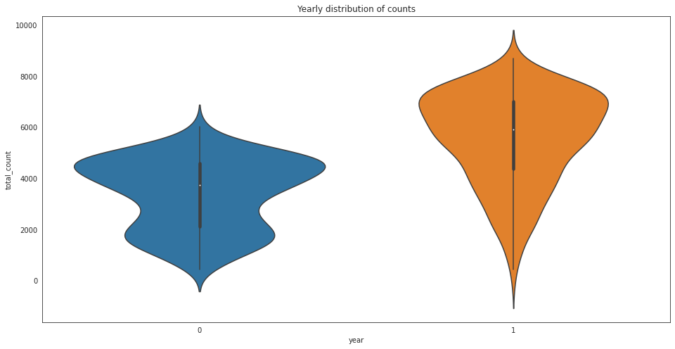

```python
fig,ax=plt.subplots(figsize=(16, 8))
#Violin plot for yearly distribution of counts
sns.violinplot(x='year',y='total_count',data=df[['year','total_count']])
ax.set_title('Yearly distribution of counts')
plt.show()
```

We can observe that the bike rental count distribution is highest in year 2012 then in year 2011.

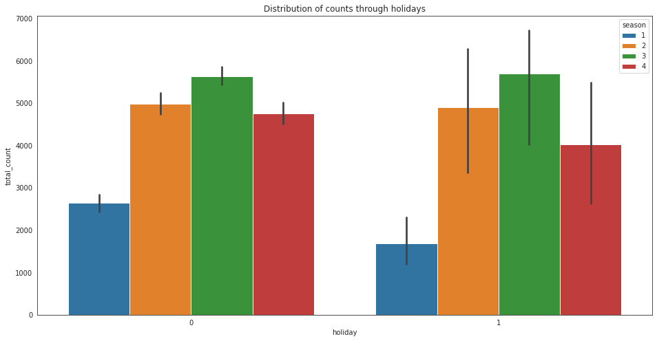

```python
fig,ax=plt.subplots(figsize=(16, 8))
#Barplot for Holiday distribution of counts
sns.barplot(data=df,x='holiday',y='total_count',hue='season')
ax.set_title('Distribution of counts through holidays')
plt.show()
```

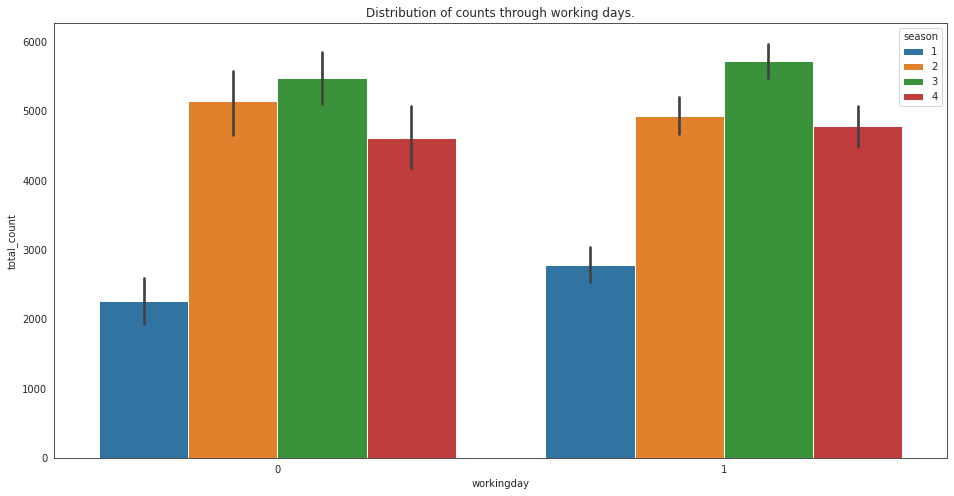

```python
fig,ax=plt.subplots(figsize=(16,8))
#Bar plot for workingday distribution of counts
sns.barplot(data=df,x='workingday',y='total_count',hue='season')
ax.set_title('Distribution of counts through working days.')
plt.show()
```

From the bar plots above we can see that the bike rental usage is **higher in working days** rather than holidays.

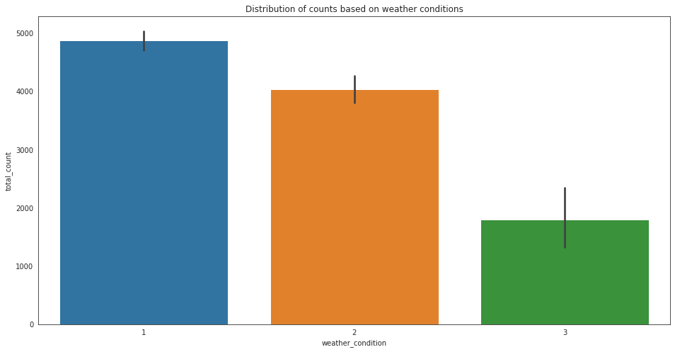

```python
fig,ax1=plt.subplots(figsize=(16,8))
#Bar plot for weather_condition distribution of counts
sns.barplot(x='weather_condition',y='total_count',data=df[['month','total_count','weather_condition']],ax=ax1)
ax1.set_title('Distribution of counts based on weather conditions')
plt.show()
```

Here we can see that the highest level of rental are:

1. During clear and partly cloudy weather
2. During mist cloudy weather
3. During light snow and light rain weather.

## Outlier analysis

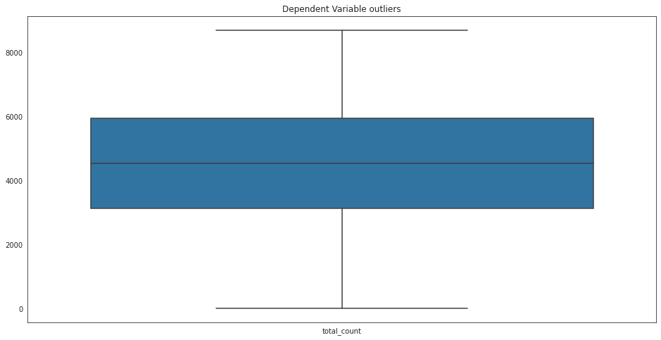

```python
fig,ax=plt.subplots(figsize=(16,8))
#Boxplot for total_count outliers
sns.boxplot(data=df[['total_count']])
ax.set_title('Dependent Variable outliers')
plt.show()
```

There are no outliers in our dependent variable.

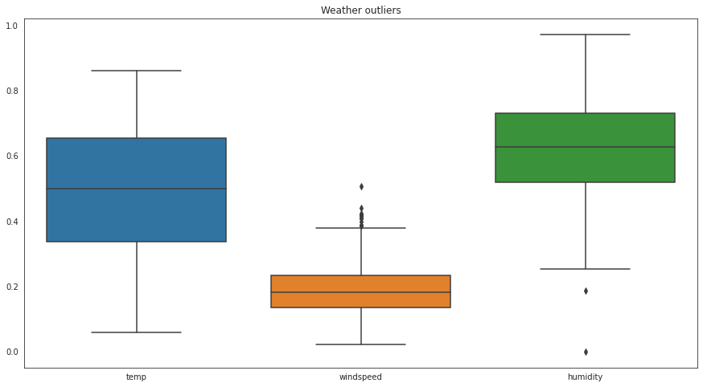

```python
fig,ax=plt.subplots(figsize=(15,8))
#Box plot for Temp_windspeed_humidity_outliers
sns.boxplot(data=df[['temp','windspeed','humidity']])
ax.set_title('Weather outliers')
plt.show()
```

Some outliers are present in windspeed and humidity variable.

### Removing outliers

To fill outliers I first remove them and then i fill with the mean of the explanatory variable.

```python
wind_humidity=pd.DataFrame(df,columns=['windspeed','humidity'])
cnames=['windspeed','humidity']

for i in cnames:
    q75, q25 = np.percentile(wind_humidity.loc[:,i],[75,25])
    iqr=q75-q25
    min=q25-(iqr*1.5)
    max=q75+(iqr*1.5)
    wind_humidity.loc[wind_humidity.loc[:,i]<min,:i]=np.nan  #Replace with NA
    wind_humidity.loc[wind_humidity.loc[:,i]>max,:i]=np.nan  #Replace with NA

#Imputating the outliers by mean Imputation
wind_humidity['windspeed']=wind_humidity['windspeed'].fillna(wind_humidity['windspeed'].mean())
wind_humidity['humidity']=wind_humidity['humidity'].fillna(wind_humidity['humidity'].mean())
```

```python
df['windspeed']=df['windspeed'].replace(wind_humidity['windspeed'])
df['humidity']=df['humidity'].replace(wind_humidity['humidity'])
df.head()
```

|  | id | datetime | season | year | month | holiday | weekday | workingday | weather_condition | temp | atemp | humidity | windspeed | casual | registered | total_count |
| --- | --- | --- | --- | --- | --- | --- | --- | --- | --- | --- | --- | --- | --- | --- | --- | --- |
| 0 | 1 | 2011-01-01 | 1 | 0 | 1 | 0 | 6 | 0 | 2 | 0.344167 | 0.363625 | 0.805833 | 0.160446 | 331 | 654 | 985 |
| 1 | 2 | 2011-01-02 | 1 | 0 | 1 | 0 | 0 | 0 | 2 | 0.363478 | 0.353739 | 0.696087 | 0.248539 | 131 | 670 | 801 |
| 2 | 3 | 2011-01-03 | 1 | 0 | 1 | 0 | 1 | 1 | 1 | 0.196364 | 0.189405 | 0.437273 | 0.248309 | 120 | 1229 | 1349 |
| 3 | 4 | 2011-01-04 | 1 | 0 | 1 | 0 | 2 | 1 | 1 | 0.200000 | 0.212122 | 0.590435 | 0.160296 | 108 | 1454 | 1562 |
| 4 | 5 | 2011-01-05 | 1 | 0 | 1 | 0 | 3 | 1 | 1 | 0.226957 | 0.229270 | 0.436957 | 0.186900 | 82 | 1518 | 1600 |

## Normal Probability Plot

is a graphical technique to identify substantive departures from normality and also it tells about goodness of fit.

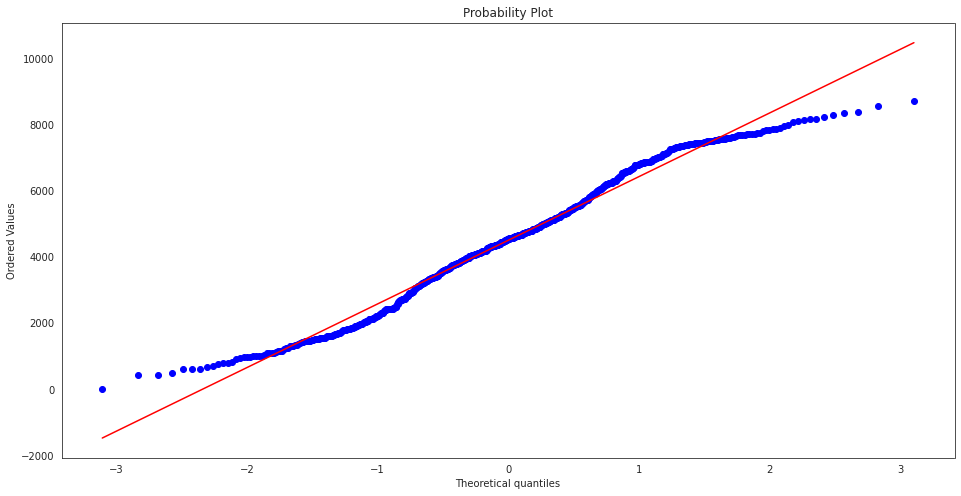

```python
fig=plt.figure(figsize=(16,8))
scipy.stats.probplot(df.total_count.tolist(),dist='norm',plot=plt)
plt.show()
```

Some target variable data points are deviates from normality.

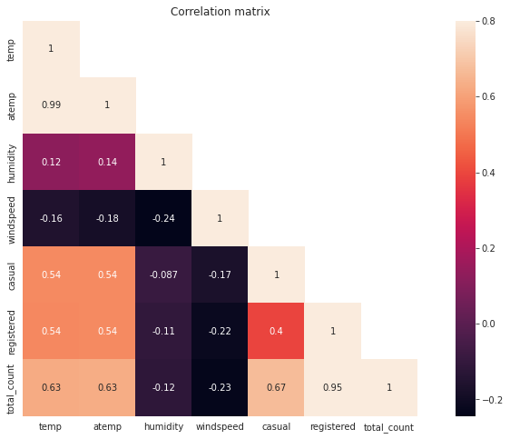

```python
#Create the correlation matrix
matrix=df[["temp","atemp","humidity","windspeed","casual","registered","total_count"]].corr()
mask=np.array(matrix)
mask[np.tril_indices_from(mask)]=False
fig,ax=plt.subplots(figsize=(15,8))
sns.heatmap(matrix,mask=mask,vmax=0.8,square=True,annot=True,ax=ax)
ax.set_title('Correlation matrix')
plt.show()
```

We can observed that some features are positively correlated or some are negatively correlated to each other. The temp and atemp are highly positively correlated to each other, it means that both are carrying same information so that's why i don't consider **atemp** as a training feature.

The total_count, casual and registered are highly positively correlated to each other and not relevant for the training of the model.

# Modelling

```python
model_results = dict()
X_train, X_test, y_train, y_test = train_test_split(df.iloc[:,0:-3], df.iloc[:,-1], test_size=0.3, random_state=42)

#Reset train index values
X_train.reset_index(inplace=True)
y_train=y_train.reset_index()

# Reset train index values
X_test.reset_index(inplace=True)
y_test=y_test.reset_index()

print(X_train.shape,X_test.shape,y_train.shape,y_test.shape)
print(y_train.head())
print(y_test.head())
```

```
(511, 14) (220, 14) (511, 2) (220, 2)
   index  total_count
0    223         4905
1    684         5445
2    685         5698
3    163         5020
4    394         3624
   index  total_count
0    703         6606
1     33         1550
2    300         3747
3    456         6041
4    633         7538
```

```python
train_attributes = X_train[['season','month','year','weekday','holiday','workingday','weather_condition','humidity','temp','windspeed']]
test_attributes = X_test[['season','month','year','weekday','holiday','workingday','humidity','temp','windspeed','weather_condition']]
cat_attributes = ['season','holiday','workingday','weather_condition','year']
num_attributes = ['temp','windspeed','humidity','month','weekday']
```

```python
#Encode the categorical features to numeric
train_encoded_attributes=pd.get_dummies(train_attributes,columns=cat_attributes)
print('Shape of transfomed dataframe::',train_encoded_attributes.shape)
train_encoded_attributes.head()
```

```
Shape of transfomed dataframe:: (511, 18)
```

|  | month | weekday | humidity | temp | windspeed | season_1 | season_2 | season_3 | season_4 | holiday_0 | holiday_1 | workingday_0 | workingday_1 | weather_condition_1 | weather_condition_2 | weather_condition_3 | year_0 | year_1 |
| --- | --- | --- | --- | --- | --- | --- | --- | --- | --- | --- | --- | --- | --- | --- | --- | --- | --- | --- |
| 0 | 8 | 5 | 0.415000 | 0.708333 | 0.125621 | 0 | 0 | 1 | 0 | 1 | 0 | 0 | 1 | 1 | 0 | 0 | 1 | 0 |
| 1 | 11 | 4 | 0.620417 | 0.321667 | 0.152987 | 0 | 0 | 0 | 1 | 1 | 0 | 0 | 1 | 0 | 1 | 0 | 0 | 1 |
| 2 | 11 | 5 | 0.524583 | 0.345000 | 0.171025 | 0 | 0 | 0 | 1 | 1 | 0 | 0 | 1 | 1 | 0 | 0 | 0 | 1 |
| 3 | 6 | 1 | 0.494583 | 0.635000 | 0.305350 | 0 | 1 | 0 | 0 | 1 | 0 | 0 | 1 | 1 | 0 | 0 | 1 | 0 |
| 4 | 1 | 1 | 0.400833 | 0.269167 | 0.215792 | 1 | 0 | 0 | 0 | 1 | 0 | 0 | 1 | 1 | 0 | 0 | 0 | 1 |

```python
test_encoded_attributes=pd.get_dummies(test_attributes,columns=cat_attributes)
print('Shape of transformed dataframe :',test_encoded_attributes.shape)
test_encoded_attributes.head(5)
```

```
Shape of transformed dataframe : (220, 18)
```

|  | month | weekday | humidity | temp | windspeed | season_1 | season_2 | season_3 | season_4 | holiday_0 | holiday_1 | workingday_0 | workingday_1 | weather_condition_1 | weather_condition_2 | weather_condition_3 | year_0 | year_1 |
| --- | --- | --- | --- | --- | --- | --- | --- | --- | --- | --- | --- | --- | --- | --- | --- | --- | --- | --- |
| 0 | 12 | 2 | 0.733750 | 0.475833 | 0.174129 | 0 | 0 | 0 | 1 | 1 | 0 | 0 | 1 | 1 | 0 | 0 | 0 | 1 |
| 1 | 2 | 4 | 0.437826 | 0.186957 | 0.277752 | 1 | 0 | 0 | 0 | 1 | 0 | 0 | 1 | 1 | 0 | 0 | 1 | 0 |
| 2 | 10 | 5 | 0.585833 | 0.330833 | 0.229479 | 0 | 0 | 0 | 1 | 1 | 0 | 0 | 1 | 0 | 1 | 0 | 1 | 0 |
| 3 | 4 | 0 | 0.676250 | 0.425833 | 0.172267 | 0 | 1 | 0 | 0 | 1 | 0 | 1 | 0 | 0 | 1 | 0 | 0 | 1 |
| 4 | 9 | 2 | 0.570000 | 0.550000 | 0.236321 | 0 | 0 | 0 | 1 | 1 | 0 | 0 | 1 | 1 | 0 | 0 | 0 | 1 |

# Decision Tree

```python
#Training dataset for modelling
X_train=train_encoded_attributes
y_train=y_train.total_count.values
```

```python
dtr=DecisionTreeRegressor(min_samples_split=2,max_leaf_nodes=10)
```

```python
dtr.fit(X_train,y_train)
```

```
DecisionTreeRegressor(max_leaf_nodes=10)
```

```python
#Accuracy score of the model
dtr_score=dtr.score(X_train,y_train)
model_results["DT"] = dtr_score
print('Accuracy of model :',dtr_score)
```

```
Accuracy of model : 0.8082151777539757
```

```python
# export the learned model to tree
dot_data = tree.export_graphviz(dtr, out_file=None)
graph = graphviz.Source(dot_data)
graph
```

[figure not shown]

```python
predict=cross_val_predict(dtr,X_train,y_train,cv=3)
predict
```

[output not shown]

[output cut: 73 more lines]

[output not shown]

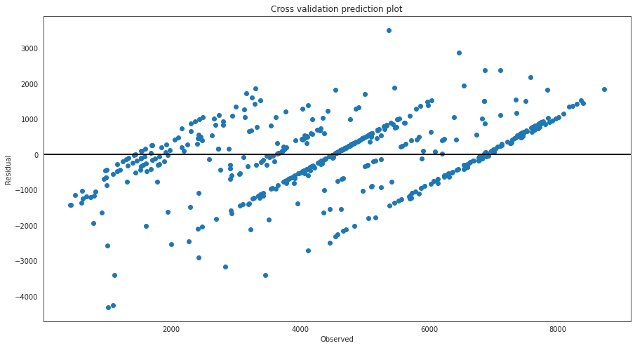

```python
# Cross validation prediction plot
fig,ax=plt.subplots(figsize=(15,8))
ax.scatter(y_train,y_train-predict)
ax.axhline(lw=2,color='black')
ax.set_title('Cross validation prediction plot')
ax.set_xlabel('Observed')
ax.set_ylabel('Residual')
plt.show()
```

The plot shows the variance between actual target value and predicted target value.

```python
#R-squared scores
r2_scores = cross_val_score(dtr, X_train, y_train, cv=3)
R2_avg = np.average(r2_scores)
model_results["DT_R2"] = R2_avg
print('R-squared scores :', R2_avg)
```

```
R-squared scores : 0.7460808156442775
```

The R-squared or coefficient of determination is 0.74 on average for 3-fold cross validation, it means that predictor is only able to predict 74% of the variance in the target variable which is contributed by independent variables.

## Feature Selection with Decision Tree

```python
importance = dtr.feature_importances_
```

```python
for i,v in enumerate(importance):
	print('Feature: %0d, Score: %.5f' % (i,v))
```

```
Feature: 0, Score: 0.00000
Feature: 1, Score: 0.00000
Feature: 2, Score: 0.04719
Feature: 3, Score: 0.59359
Feature: 4, Score: 0.00000
Feature: 5, Score: 0.01806
Feature: 6, Score: 0.00000
Feature: 7, Score: 0.00000
Feature: 8, Score: 0.02506
Feature: 9, Score: 0.00000
Feature: 10, Score: 0.00000
Feature: 11, Score: 0.00000
Feature: 12, Score: 0.00000
Feature: 13, Score: 0.00000
Feature: 14, Score: 0.00000
Feature: 15, Score: 0.00000
Feature: 16, Score: 0.25797
Feature: 17, Score: 0.05812
```

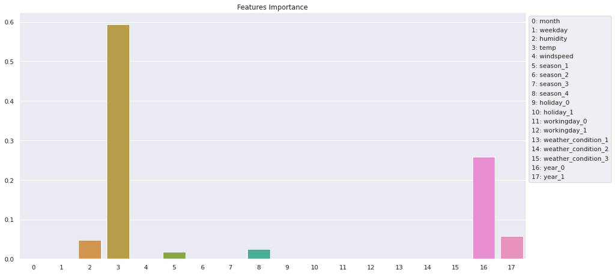

```python
sns.set(rc = {'figure.figsize':(16,8)})
sns.barplot(x=[x for x in range(len(importance))], y=importance).set_title("Features Importance")
plt.legend(labels=[f"{x}: {y}" for x, y in enumerate(X_train.columns)], loc = 2, bbox_to_anchor = (1,1), handletextpad=0, handlelength=0)
```

# Random Forest

Now i will use only variables that have a positive importance coefficient

```python
importance_ix = [x for x, y in enumerate(importance) if y>0]
importance_ix
```

```
[2, 3, 5, 8, 16, 17]
```

```python
X_train_by_importance = train_encoded_attributes.iloc[:, importance_ix]
X_train_by_importance.head()
```

|  | humidity | temp | season_1 | season_4 | year_0 | year_1 |
| --- | --- | --- | --- | --- | --- | --- |
| 0 | 0.415000 | 0.708333 | 0 | 0 | 1 | 0 |
| 1 | 0.620417 | 0.321667 | 0 | 1 | 0 | 1 |
| 2 | 0.524583 | 0.345000 | 0 | 1 | 0 | 1 |
| 3 | 0.494583 | 0.635000 | 0 | 0 | 1 | 0 |
| 4 | 0.400833 | 0.269167 | 1 | 0 | 0 | 1 |

# First let's just test the model without var selection

```python
X_train=train_encoded_attributes
rf=RandomForestRegressor(n_estimators=200)
```

```python
#Fit the trained model
rf.fit(X_train,y_train)
```

```
RandomForestRegressor(n_estimators=200)
```

```python
#accuracy of the model
rf_score =rf.score(X_train,y_train)
model_results["RF"] = rf_score
print('Accuracy of the model :',rf_score)
```

```
Accuracy of the model : 0.9804123303253397
```

```python
#Cross validation prediction
predict=cross_val_predict(rf,X_train,y_train,cv=3)
predict
```

[output not shown]

[output cut: 31 more lines]

[output not shown]

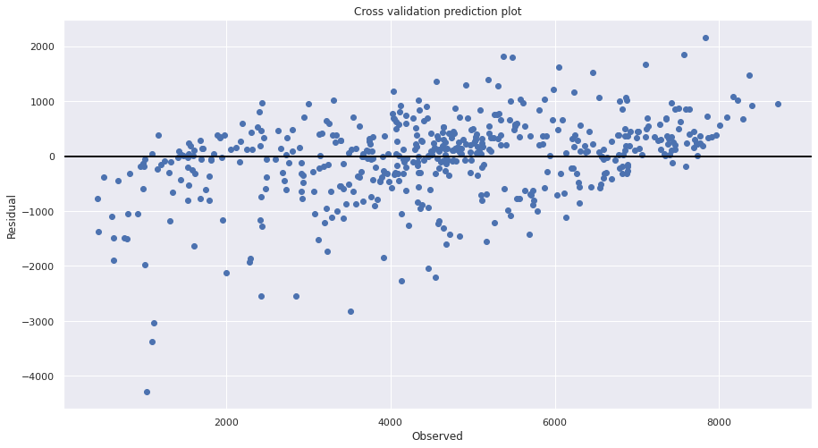

```python
#Cross validation prediction plot
fig,ax=plt.subplots(figsize=(15,8))
ax.scatter(y_train,y_train-predict)
ax.axhline(lw=2,color='black')
ax.set_title('Cross validation prediction plot')
ax.set_xlabel('Observed')
ax.set_ylabel('Residual')
plt.show()
```

```python
#R-squared scores
r2_scores = cross_val_score(rf, X_train, y_train, cv=3)
r2_avg = np.average(r2_scores)
model_results["RF_R2"] = r2_avg
print('R-squared scores :', r2_avg)
```

```
R-squared scores : 0.8467837975005086
```

The predictor is only able to predict 85% of the variance in the target variable which is contributed by independent variables.

```python
#predict the model
X_test=test_encoded_attributes
y_test=y_test.total_count.values
rf_pred=rf.predict(X_test)
rf_pred
```

[output not shown]

```python
#Root mean square error
rmse = math.sqrt(metrics.mean_squared_error(y_test,rf_pred))
model_results["RF_RMSE"] = rmse
print('Root mean square error :',rmse)
#Mean absolute error
mae=metrics.mean_absolute_error(y_test,rf_pred)
print('Mean absolute error :',mae)
```

```
Root mean square error : 646.4057372445062
Mean absolute error : 432.1116136363636
```

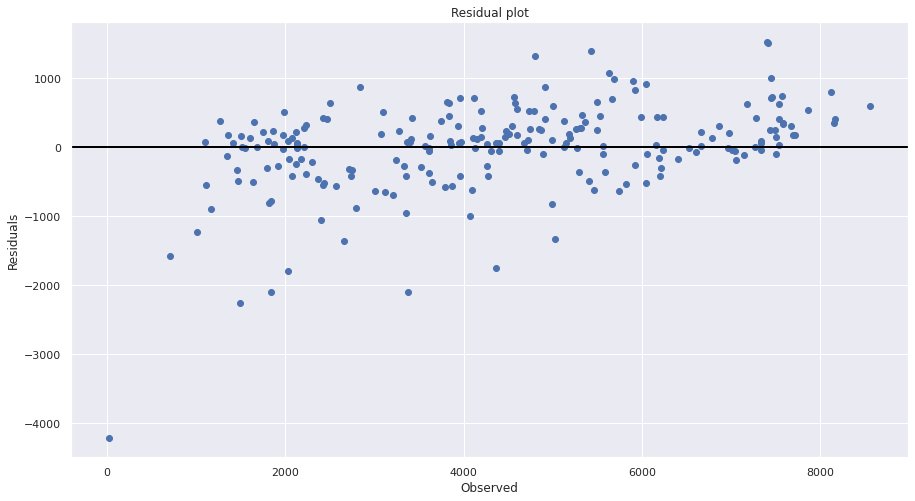

```python
#Residual scatter plot
fig, ax = plt.subplots(figsize=(15,8))
residuals=y_test-rf_pred
ax.scatter(y_test, residuals)
ax.axhline(lw=2,color='black')
ax.set_xlabel('Observed')
ax.set_ylabel('Residuals')
ax.set_title('Residual plot')
plt.show()
```

```python
test_data=pd.DataFrame(y_test,columns=['y_test'])
predicted_data_rf=pd.DataFrame(rf_pred,columns=['rf_pred'])
overview=pd.merge(test_data,predicted_data_rf,left_index=True,right_index=True)
overview
```

|  | y_test | rf_pred |
| --- | --- | --- |
| 0 | 6606 | 6674.480 |
| 1 | 1550 | 1565.970 |
| 2 | 3747 | 3370.175 |
| 3 | 6041 | 5127.605 |
| 4 | 7538 | 7512.285 |
| ... | ... | ... |
| 215 | 2659 | 4017.520 |
| 216 | 7338 | 7281.135 |
| 217 | 6978 | 6776.340 |
| 218 | 4795 | 3469.760 |
| 219 | 3855 | 3821.640 |

220 rows × 2 columns

# Now with VAR Selection

```python
X_train=X_train_by_importance
rf=RandomForestRegressor(n_estimators=200)
```

```python
#Fit the trained model
rf.fit(X_train,y_train)
```

```
RandomForestRegressor(n_estimators=200)
```

```python
#accuracy of the model
rf_score =rf.score(X_train,y_train)
model_results["RF_with_var_selection"] = rf_score
print('Accuracy of the model :', rf_score)
```

```
Accuracy of the model : 0.975400452279929
```

```python
#Cross validation prediction
predict=cross_val_predict(rf,X_train,y_train,cv=3)
predict
```

[output not shown]

[output cut: 31 more lines]

[output not shown]

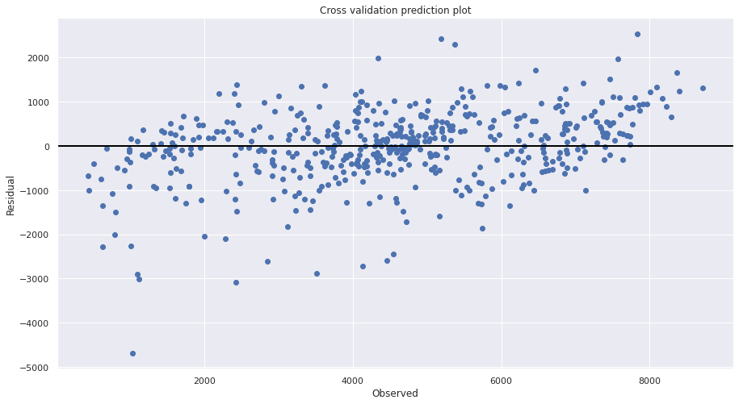

```python
#Cross validation prediction plot
fig,ax=plt.subplots(figsize=(15,8))
ax.scatter(y_train,y_train-predict)
ax.axhline(lw=2,color='black')
ax.set_title('Cross validation prediction plot')
ax.set_xlabel('Observed')
ax.set_ylabel('Residual')
plt.show()
```

```python
#R-squared scores
r2_scores = cross_val_score(rf, X_train, y_train, cv=3)
r2_avg = np.average(r2_scores)
model_results["RF_with_var_selection_R2"] = r2_avg
print('R-squared scores :', r2_avg)
```

```
R-squared scores : 0.8159150858636544
```

The predictor is only able to predict 81% of the variance in the target variable which is contributed by independent variables.

```python
#predict the model
X_test=test_encoded_attributes.iloc[:, importance_ix]
rf_pred=rf.predict(X_test)
rf_pred
```

[output not shown]

```python
#Root mean square error
rmse = math.sqrt(metrics.mean_squared_error(y_test,rf_pred))
print('Root mean square error :',rmse)
model_results["RF_RMSE_VARSELECT"] = rmse
#Mean absolute error
mae=metrics.mean_absolute_error(y_test,rf_pred)
print('Mean absolute error :',mae)
```

```
Root mean square error : 764.8716792322689
Mean absolute error : 531.1631818181818
```

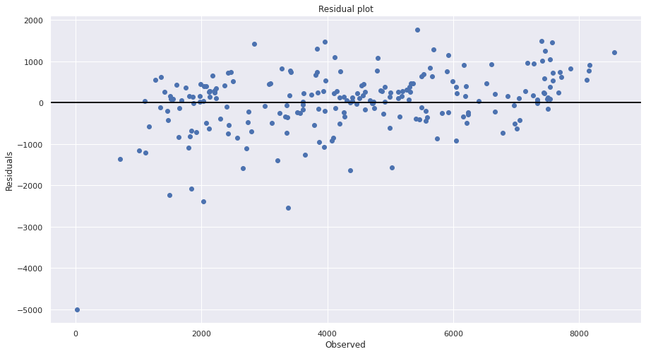

```python
#Residual scatter plot
fig, ax = plt.subplots(figsize=(15,8))
residuals=y_test-rf_pred
ax.scatter(y_test, residuals)
ax.axhline(lw=2,color='black')
ax.set_xlabel('Observed')
ax.set_ylabel('Residuals')
ax.set_title('Residual plot')
plt.show()
```

Cross validation prediction plot tells about finite variance between actual target value and predicted target value.In this plot,some data points are have same finite variance between them and for some are not have it.

```python
test_data=pd.DataFrame(y_test,columns=['y_test'])
predicted_data_rf=pd.DataFrame(rf_pred,columns=['rf_pred'])
overview_rf=pd.merge(test_data,predicted_data_rf,left_index=True,right_index=True)
overview_rf
```

|  | y_test | rf_pred |
| --- | --- | --- |
| 0 | 6606 | 5677.485 |
| 1 | 1550 | 1451.800 |
| 2 | 3747 | 3557.885 |
| 3 | 6041 | 5650.755 |
| 4 | 7538 | 7449.085 |
| ... | ... | ... |
| 215 | 2659 | 4242.710 |
| 216 | 7338 | 7352.725 |
| 217 | 6978 | 7488.870 |
| 218 | 4795 | 3705.965 |
| 219 | 3855 | 3997.235 |

220 rows × 2 columns

# BENCHMARK: NEURAL NETWORK

Now i will create the benchmark model

```python
from keras import backend as K
```

```python
import warnings
warnings.filterwarnings("ignore")
```

```python
X_train, X_test, y_train, y_test = train_test_split(df.drop(['total_count', 'datetime'], axis=1), df["total_count"], test_size=0.3, random_state=42)
```

```python
model = keras.Sequential([
    layers.Dense(256, activation = tf.keras.layers.ELU(), input_shape=[X_train.shape[1]]), #Input Layer
    layers.Dense(256, activation = tf.keras.layers.ELU()), #Hidden Layer
    layers.Dense(16, activation = 'relu'), #Hidden Layer
    layers.Dense(4, activation = 'relu'), #Hidden Layer
    layers.Dense(1) #Output Layer
   ])

# Compile the network :
model.compile(loss = tf.keras.losses.MeanSquaredError(),
                 optimizer = 'adam', metrics = [tf.keras.metrics.RootMeanSquaredError()])
model.summary()
```

```
Model: "sequential"
_________________________________________________________________
 Layer (type)                Output Shape              Param #
=================================================================
 dense (Dense)               (None, 256)               3840

 dense_1 (Dense)             (None, 256)               65792

 dense_2 (Dense)             (None, 16)                4112

 dense_3 (Dense)             (None, 4)                 68

 dense_4 (Dense)             (None, 1)                 5

=================================================================
Total params: 73,817
Trainable params: 73,817
Non-trainable params: 0
_________________________________________________________________
```

```python
from sklearn.preprocessing import RobustScaler
scaler = RobustScaler()
z = scaler.fit_transform(X_test)
```

```python
#Creating check point to retreive best weights
from keras.callbacks import ModelCheckpoint
```

```python
checkpoint_name = 'Weights-{epoch:03d}--{val_loss:.5f}.hdf5'
checkpoint = ModelCheckpoint(checkpoint_name, monitor='val_loss', verbose = 1, save_best_only = True, mode ='auto')
callbacks_list = [checkpoint]

# Fitting the model
history = model.fit(X_train, y_train, epochs=200, batch_size=32, validation_split = 0.2, callbacks=callbacks_list)
```

[output not shown]

[output cut: 145 more lines]

[output not shown]

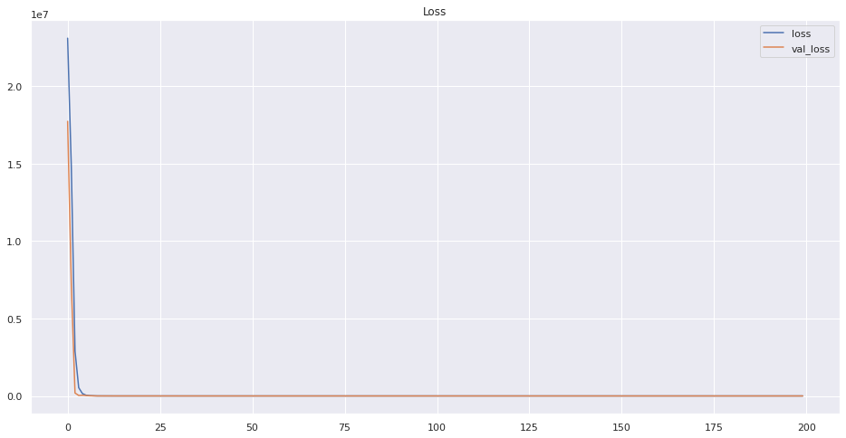

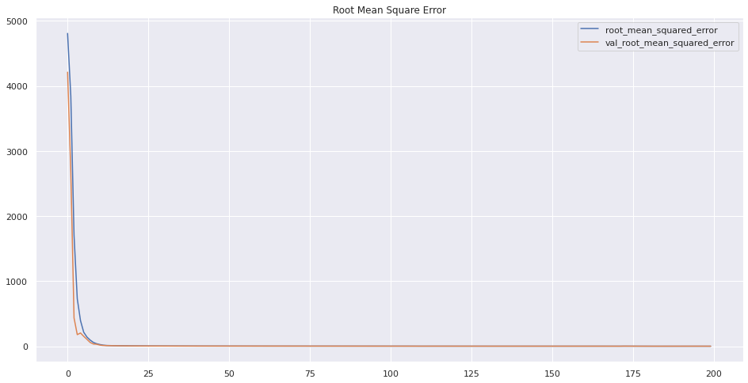

```python
#Creating Dataframe to check history
history_df = pd.DataFrame(history.history)

history_df.loc[:, ['loss', 'val_loss']].plot(title="Loss")
history_df.loc[:, ['root_mean_squared_error', 'val_root_mean_squared_error']].plot(title="Root Mean Square Error")
```

```python
prediction = model.predict(X_test)
```

```python
acc = metrics.r2_score(y_test, prediction)*100 #Checking R2_Score
model_results["NN_R2"] = acc
print('R2_Score',acc)

met = np.sqrt(metrics.mean_squared_error(y_test, prediction)) #Calculating RMSE
model_results["NN_RMSE"] = met
print('RMSE : ', met)

var = (metrics.explained_variance_score(y_test, prediction))
```

```
R2_Score 99.99940294051937
RMSE :  4.874094191997651
```

```python
test_data_nn=pd.DataFrame(y_test.values,columns=['y_test'])
predicted_data_nn=pd.DataFrame(prediction,columns=['nn_pred'])
overview_nn=pd.merge(test_data_nn,predicted_data_nn,left_index=True,right_index=True)
overview_nn
```

|  | y_test | nn_pred |
| --- | --- | --- |
| 0 | 6606 | 6607.690918 |
| 1 | 1550 | 1551.141602 |
| 2 | 3747 | 3748.674072 |
| 3 | 6041 | 6042.937988 |
| 4 | 7538 | 7538.611328 |
| ... | ... | ... |
| 215 | 2659 | 2659.055176 |
| 216 | 7338 | 7338.385742 |
| 217 | 6978 | 6978.872070 |
| 218 | 4795 | 4794.220703 |
| 219 | 3855 | 3855.808105 |

220 rows × 2 columns

```python
overview_nn["y_test"].corr(overview_nn["nn_pred"])
```

```
0.9999974033463701
```

```python
model_results
```

```
{'DT': 0.8082151777539757,
 'DT_R2': 0.7460808156442775,
 'NN_R2': 99.99940294051937,
 'NN_RMSE': 4.874094191997651,
 'RF': 0.9804123303253397,
 'RF_R2': 0.8467837975005086,
 'RF_RMSE': 646.4057372445062,
 'RF_RMSE_VARSELECT': 764.8716792322689,
 'RF_with_var_selection': 0.975400452279929,
 'RF_with_var_selection_R2': 0.8159150858636544}
```

We can see that all the models performed really well.

And the R2 shows that Neural Network explain 99,99% of the variance!